# Week 6 Exercises

# Exercise 1

The data frames df_w and df_f represent repeated measures data from 60 participants. Variables F1-F3 and W1-W3 are “sub-variables” that will be used to make two composite variables F_total and W_total, respectively.

#### 1.1

Merge the two data frames together.

```r
df_w
```

| id | session | group | W1 | W2 | W3 |
| --- | --- | --- | --- | --- | --- |
| 1 | 1 | 1 | 2 | 3 | 2 |
| 1 | 2 | 1 | 1 | 0 | 0 |
| 2 | 1 | 1 | 0 | 2 | 1 |
| 2 | 2 | 1 | 3 | 2 | 0 |
| 3 | 1 | 1 | 3 | 2 | 0 |
| 3 | 2 | 1 | 0 | 3 | 3 |
| 4 | 1 | 1 | 3 | 1 | 2 |
| 4 | 2 | 1 | 1 | 0 | 1 |
| 5 | 1 | 1 | 2 | 0 | 1 |
| 5 | 2 | 1 | 2 | 1 | 1 |

[output cut: 110 more lines]

```r
df_f
```

| id | session | group | F1 | F2 | F3 |
| --- | --- | --- | --- | --- | --- |
| 1 | 2 | 1 | 0 | 0 | 3 |
| 1 | 1 | 1 | 3 | 0 | 0 |
| 2 | 2 | 1 | 2 | 0 | 2 |
| 2 | 1 | 1 | 0 | 0 | 0 |
| 3 | 2 | 1 | 1 | 0 | 0 |
| 3 | 1 | 1 | 0 | 0 | 0 |
| 4 | 2 | 1 | 2 | 0 | 2 |
| 4 | 1 | 1 | 2 | 0 | 0 |
| 5 | 2 | 1 | 1 | 0 | 0 |
| 5 | 1 | 1 | 1 | 0 | 0 |

[output cut: 110 more lines]

```r
df <- merge(df_w, df_f, all = TRUE)
df
```

| id | session | group | W1 | W2 | W3 | F1 | F2 | F3 |
| --- | --- | --- | --- | --- | --- | --- | --- | --- |
| 1 | 1 | 1 | 2 | 3 | 2 | 3 | 0 | 0 |
| 1 | 2 | 1 | 1 | 0 | 0 | 0 | 0 | 3 |
| 10 | 1 | 1 | 0 | 3 | 0 | 2 | 0 | 0 |
| 10 | 2 | 1 | 2 | 3 | 3 | 1 | 0 | 0 |
| 11 | 1 | 1 | 1 | 2 | 2 | 2 | 0 | 0 |
| 11 | 2 | 1 | 3 | 2 | 3 | 0 | 0 | 3 |
| 12 | 1 | 1 | 2 | 2 | 2 | 0 | 0 | 0 |
| 12 | 2 | 1 | 2 | 0 | 0 | 0 | 0 | 0 |
| 13 | 1 | 1 | 2 | 0 | 2 | 0 | 0 | 0 |
| 13 | 2 | 1 | 1 | 2 | 2 | 0 | 0 | 0 |

[output cut: 110 more lines]

#### 1.2

Using the merged data frame, create the **composite variables F_total and W_total, which are the sums of F1-F3 and W1-W3, respectively** (i.e. their values can range from 0 to 9).

```r
df %>%
  rowwise() %>%
  mutate(F_total = sum(c(F1, F2, F3))) -> df
df %>%
  rowwise() %>%
  mutate(W_total = sum(c(W1, W2, W3))) -> df
df
```

| id | session | group | W1 | W2 | W3 | F1 | F2 | F3 | F_total | W_total |
| --- | --- | --- | --- | --- | --- | --- | --- | --- | --- | --- |
| 1 | 1 | 1 | 2 | 3 | 2 | 3 | 0 | 0 | 3 | 7 |
| 1 | 2 | 1 | 1 | 0 | 0 | 0 | 0 | 3 | 3 | 1 |
| 10 | 1 | 1 | 0 | 3 | 0 | 2 | 0 | 0 | 2 | 3 |
| 10 | 2 | 1 | 2 | 3 | 3 | 1 | 0 | 0 | 1 | 8 |
| 11 | 1 | 1 | 1 | 2 | 2 | 2 | 0 | 0 | 2 | 5 |
| 11 | 2 | 1 | 3 | 2 | 3 | 0 | 0 | 3 | 3 | 8 |
| 12 | 1 | 1 | 2 | 2 | 2 | 0 | 0 | 0 | 0 | 6 |
| 12 | 2 | 1 | 2 | 0 | 0 | 0 | 0 | 0 | 0 | 2 |
| 13 | 1 | 1 | 2 | 0 | 2 | 0 | 0 | 0 | 0 | 4 |
| 13 | 2 | 1 | 1 | 2 | 2 | 0 | 0 | 0 | 0 | 5 |

[output cut: 110 more lines]

# Exercise 2

#### 2.1

Visualise the distributions of F_total and W_total for the two groups and measurement sessions (for example as boxplots).

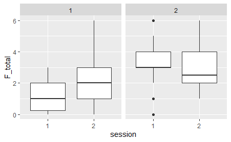

```r
df %>%
  ggplot(aes(session, F_total)) +
  geom_boxplot() +
  facet_wrap(~group)
```

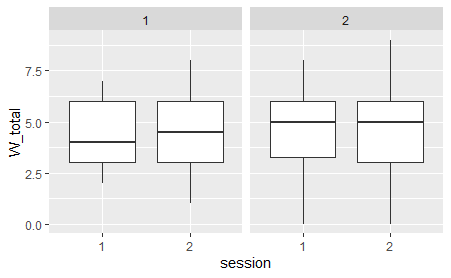

```r
df %>%
  ggplot(aes(session, W_total)) +
  geom_boxplot() +
  facet_wrap(~group)
```

#### 2.2

Fit a linear regression model with F_total as the DV, and session and group as predictors.

```r
Model <- lm(F_total ~ session + group, data = df)

summary(Model)
```

```
Call:
lm(formula = F_total ~ session + group, data = df)

Residuals:
    Min      1Q  Median      3Q     Max
-2.9667 -1.2000  0.0333  1.0333  4.0333

Coefficients:
            Estimate Std. Error t value Pr(>|t|)
(Intercept)   1.7333     0.2422   7.156 7.84e-11 ***
session2      0.2333     0.2797   0.834    0.406
group2        1.2333     0.2797   4.409 2.31e-05 ***
---
Signif. codes:
0 ‘***’ 0.001 ‘**’ 0.01 ‘*’ 0.05 ‘.’ 0.1 ‘ ’ 1

Residual standard error: 1.532 on 117 degrees of freedom
Multiple R-squared:  0.1469,    Adjusted R-squared:  0.1323
F-statistic: 10.07 on 2 and 117 DF,  p-value: 9.224e-05
```

#### 2.3

Look at the means of F_total by group and session. How are they linked to the linear regression model coefficients?

```r
# look at the mean of 'F_total' by group and session
df_mean <- df %>%
  group_by(group, session) %>%
  summarise(mean_F_total = mean(F_total)) %>%
  ungroup
df_mean
```

| group | session | mean_F_total |
| --- | --- | --- |
| 1 | 1 | 1.400000 |
| 1 | 2 | 2.300000 |
| 2 | 1 | 3.300000 |
| 2 | 2 | 2.866667 |

```r
# how the mean link to lm coefficients
```

# Exercise 3

Visualise the [anscombe dataset](https://rdrr.io/r/datasets/anscombe.html) using ggplot2.

```r
# Read data
library(datasets)
anscombe
```

| x1 | x2 | x3 | x4 | y1 | y2 | y3 | y4 |
| --- | --- | --- | --- | --- | --- | --- | --- |
| 10 | 10 | 10 | 8 | 8.04 | 9.14 | 7.46 | 6.58 |
| 8 | 8 | 8 | 8 | 6.95 | 8.14 | 6.77 | 5.76 |
| 13 | 13 | 13 | 8 | 7.58 | 8.74 | 12.74 | 7.71 |
| 9 | 9 | 9 | 8 | 8.81 | 8.77 | 7.11 | 8.84 |
| 11 | 11 | 11 | 8 | 8.33 | 9.26 | 7.81 | 8.47 |
| 14 | 14 | 14 | 8 | 9.96 | 8.10 | 8.84 | 7.04 |
| 6 | 6 | 6 | 8 | 7.24 | 6.13 | 6.08 | 5.25 |
| 4 | 4 | 4 | 19 | 4.26 | 3.10 | 5.39 | 12.50 |
| 12 | 12 | 12 | 8 | 10.84 | 9.13 | 8.15 | 5.56 |
| 7 | 7 | 7 | 8 | 4.82 | 7.26 | 6.42 | 7.91 |

[output cut: 1 more lines]

```r
str(anscombe)
```

```
'data.frame':   11 obs. of  8 variables:
 $ x1: num  10 8 13 9 11 14 6 4 12 7 ...
 $ x2: num  10 8 13 9 11 14 6 4 12 7 ...
 $ x3: num  10 8 13 9 11 14 6 4 12 7 ...
 $ x4: num  8 8 8 8 8 8 8 19 8 8 ...
 $ y1: num  8.04 6.95 7.58 8.81 8.33 ...
 $ y2: num  9.14 8.14 8.74 8.77 9.26 8.1 6.13 3.1 9.13 7.26 ...
 $ y3: num  7.46 6.77 12.74 7.11 7.81 ...
 $ y4: num  6.58 5.76 7.71 8.84 8.47 7.04 5.25 12.5 5.56 7.91 ...
```

```r
summary(anscombe)
```

```
       x1             x2             x3
 Min.   : 4.0   Min.   : 4.0   Min.   : 4.0
 1st Qu.: 6.5   1st Qu.: 6.5   1st Qu.: 6.5
 Median : 9.0   Median : 9.0   Median : 9.0
 Mean   : 9.0   Mean   : 9.0   Mean   : 9.0
 3rd Qu.:11.5   3rd Qu.:11.5   3rd Qu.:11.5
 Max.   :14.0   Max.   :14.0   Max.   :14.0
       x4           y1               y2
 Min.   : 8   Min.   : 4.260   Min.   :3.100
 1st Qu.: 8   1st Qu.: 6.315   1st Qu.:6.695
 Median : 8   Median : 7.580   Median :8.140
 Mean   : 9   Mean   : 7.501   Mean   :7.501
 3rd Qu.: 8   3rd Qu.: 8.570   3rd Qu.:8.950
 Max.   :19   Max.   :10.840   Max.   :9.260
       y3              y4
 Min.   : 5.39   Min.   : 5.250
 1st Qu.: 6.25   1st Qu.: 6.170
 Median : 7.11   Median : 7.040
 Mean   : 7.50   Mean   : 7.501
 3rd Qu.: 7.98   3rd Qu.: 8.190
 Max.   :12.74   Max.   :12.500
```

```r
# Calculate mean of x1, x2, x3 and x4 to 'x'; calculate mean of y1, y2, y3 and y4 to 'y'
library(tidyverse)
anscombe %>%
 rowwise() %>%
 mutate(x = mean(c(x1, x2, x3, x4))) -> anscombe
anscombe %>%
 rowwise() %>%
 mutate(y = mean(c(y1, y2, y3, y4))) -> anscombe
anscombe
```

| x1 | x2 | x3 | x4 | y1 | y2 | y3 | y4 | x | y |
| --- | --- | --- | --- | --- | --- | --- | --- | --- | --- |
| 10 | 10 | 10 | 8 | 8.04 | 9.14 | 7.46 | 6.58 | 9.50 | 7.8050 |
| 8 | 8 | 8 | 8 | 6.95 | 8.14 | 6.77 | 5.76 | 8.00 | 6.9050 |
| 13 | 13 | 13 | 8 | 7.58 | 8.74 | 12.74 | 7.71 | 11.75 | 9.1925 |
| 9 | 9 | 9 | 8 | 8.81 | 8.77 | 7.11 | 8.84 | 8.75 | 8.3825 |
| 11 | 11 | 11 | 8 | 8.33 | 9.26 | 7.81 | 8.47 | 10.25 | 8.4675 |
| 14 | 14 | 14 | 8 | 9.96 | 8.10 | 8.84 | 7.04 | 12.50 | 8.4850 |
| 6 | 6 | 6 | 8 | 7.24 | 6.13 | 6.08 | 5.25 | 6.50 | 6.1750 |
| 4 | 4 | 4 | 19 | 4.26 | 3.10 | 5.39 | 12.50 | 7.75 | 6.3125 |
| 12 | 12 | 12 | 8 | 10.84 | 9.13 | 8.15 | 5.56 | 11.00 | 8.4200 |
| 7 | 7 | 7 | 8 | 4.82 | 7.26 | 6.42 | 7.91 | 7.25 | 6.6025 |

[output cut: 1 more lines]

```r
# Visualization (Lm)
anscombe_lm <- lm(y ~ x, data = anscombe)
summary(anscombe_lm)
```

```
Call:
lm(formula = y ~ x, data = anscombe)

Residuals:
     Min       1Q   Median       3Q      Max
-0.73936 -0.12166 -0.06564  0.19779  1.00494

Coefficients:
            Estimate Std. Error t value Pr(>|t|)
(Intercept)  3.06836    0.65400   4.692  0.00113 **
x            0.49248    0.07078   6.958 6.63e-05 ***
---
Signif. codes:
0 ‘***’ 0.001 ‘**’ 0.01 ‘*’ 0.05 ‘.’ 0.1 ‘ ’ 1

Residual standard error: 0.491 on 9 degrees of freedom
Multiple R-squared:  0.8432,    Adjusted R-squared:  0.8258
F-statistic: 48.41 on 1 and 9 DF,  p-value: 6.626e-05
```

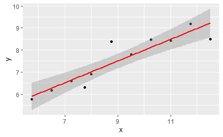

```r
library(ggplot2)
ggplot(anscombe, aes(x = x, y = y)) +
  geom_point() +
  stat_smooth(method = "lm", col = "red")
```

# Exercise 4

## I will do the alternative final assignment

Prepare a **separate R Notebook/Markdown document**, which will be the first draft of your final assignment with your own data. In the draft, include the following:

1. Outline the study design, your research question, DV(s), IV(s)
2. Data wrangling: start from reading in the raw data and show all steps
3. Plot your main result(s)

Even if you had already completed some of these steps before, please include all of them in your document. **NOTE: Return either a readable HTML document (.html or .nb.html), or an .Rmd file along with your data, to make it possible for us to review your work!** Make the document as professional-looking as possible (you can, of course, include your comments/questions in the draft). You will get feedback on the draft, based on which you can then make the final version. The final document should be a comprehensive report of your data wrangling process and results.